# Ex.1 Parsing Protein Structures

Published

April 3, 2026

# 1 Introduction

Proteins are macromolecules whose function is highly related to their three-dimensional structure. Their organization can be described in four levels, which depend on folding. Protein folding is driven by non-covalent intramolecular interactions between residues of the same polypeptide chain, whereas intermolecular interactions contribute to quaternary structure formation.

The main repository of experimentally determined macromolecuar structures is the Protein Data Bank (PDB). By applying computational analysis to the data stored in PDB files, detailed structural information can be extracted and translated into simplified representations, such as contact maps. These maps use pairwise distance matrices to provide a two-dimensional visualization of the interactions between the Cα atoms of residues within a protein or between different protein chains. In addition, specific patterns are associated with specific secondary structure elements, so it is possible to infer the spatial organization of proteins.

## 1.1 Objective

The main objective of this project is to implement computational functions to:

1. Parse PDB files to extract structural metadata and atomic coordinates.
2. Compute pairwise distance matrices between Cα atoms of protein residues.
3. Plot contact maps to characterize the structural organization and oligomeric state of the analyzed proteins.

# 2 Methods

## 2.1 Data Collection

RCSB-PDB (Research Collaboratory for Structural Bioinformatics Protein Data Bank, https://www.rcsb.org/) is a repository of experimentally determined, and also computationally predicted, structures of proteins, nucleic acids and macromolecular complexes.

The structures analyzed in this project correspond to the following proteins:

- **Plasma Retinol-Binding Protein Precursor (*Homo sapiens*, PDB ID: 1RBP)**, which is involved in retinol transport in humans.
- **Carbonic Anhydrase (*Methanosarcina thermophila*, PDB ID: 1QRE)**, which regulates pH by catalyzing the reaction between $CO_2$ and $H_2O$ to produce bicarbonate and protons.
- **Catalase (*Homo sapiens*, PDB ID: 1DGF)**, which protect cells from oxidative damage by decomposing $H_2O_2$ into water and oxygen.

## 2.2 Parsing PDB Files

**Note**

Before introducing the main functions of the project, it is important to highlight the implmentation of Function 1, which initializes all required libraries and dependencies, avoiding redundancy and improving code readability.

Taking advantage of the possibility of utilizing the PDB’s API, we have been able to extract the necessary data of PDB through a parsing function Function 4. This function extracts the relevant information for subsequent analysis by performing two independent queries to the RCSB PDB REST API (https://data.rcsb.org/redoc/index.html), one at the structural level (https://data.rcsb.org/redoc/index.html#tag/Entry-Service/operation/getEntryById) and another at the polymer entity level (https://data.rcsb.org/redoc/index.html#tag/Entity-Service/operation/getPolymerEntityById). This separation allows us to access both the experimental and general details of the protein and the specific information related to it. This function also implements a basic HTTP error-handling system through the auxiliary function Function 2, which checks the status code of the response.

Once the queries are successful, the function extracts the relevant information from the JSON responses:

|  | Metadata | Description | Source (API JSON field) |
| --- | --- | --- | --- |
| 0 | PDB ID | Unique identifier for the protein structure | rcsb_id |
| 1 | Protein Name | The name of the protein | rcsb_polymer_entity.pdbx_description |
| 2 | Source Organism | The organism from which the protein was derived | rcsb_entity_source_organism |
| 3 | Determination Method | The method used to determine the protein struc... | exptl.method |
| 4 | Authors | The researchers who contributed to the determi... | rcsb_authors |
| 5 | Release Date | The release date of the structure | rcsb_accession_info.initial_release_date |
| 6 | Resolution | The resolution of the structure, if applicable | rcsb_entry_info.resolution_combined |
| 7 | Number of Peptide Chains | The number of peptide chains present in the st... | rcsb_entry_info.polymer_entity_count_protein |
| 8 | Number of Other Molecules | The number of other molecules (e.g., ligands, ... | rcsb_entry_info.nonpolymer_entity_count |

### 2.2.1 Code Implementation

Function 1

**Click to see imported libraries.**

```python
import requests
import pandas as pd
import numpy as np
import math
import matplotlib.pyplot as plt
import matplotlib.patches as mpatches
```

Function 2

**Click to see handle_API_error function.**

```python
def handle_API_error(id, status_code = None, flag_timeout = False):
    """
    Handles HTTP request errors or timeouts and prints informative messages in
    order to centralize the management of API request errors.

    Parameters
    ----------
    id : str
        PDB ID queried in the request.
    status_code : int
        HTTP status code returned by the request.
        None by default (in case of timeout error).
    flag_timeout : bool
        Indicates whether the request failed due to a timeout.
        If True, the status_code is ignored.
        alse by default.

    Returns
    -------
        bool (True)
            True if the request was successful (status code 200).
            None returned for any error or timeout condition.
    """
    if flag_timeout: # If a timeout occurred, skip all other checks
        print(f"[408] Timeout error for ID: {id}.")

    else:
        if status_code == 200: # If the request was successful, returns True
            return True

        elif status_code == 301 or status_code == 302:
            # Resource has been permanently or temporarily moved
            print(f"[301] or [302] The object was moved to other route")

        elif status_code == 400:
            # Request processed but considered unsuccessful
            print(f"[400] Not valid ID: {id}")

        elif status_code == 404:
            # Request processed but no result was obtained
            print(f"[404] Result not found for ID: {id}")

        elif status_code == 429:
            # Request rejected due to request rate limits
            print(f"[429] Error: Too many requests.")

        elif status_code == 500 or status_code == 503:
            # Request failed due to internal server issues
            print("[500] or [503] Internal Server Error")

        else: # For any other error status code
            print(f"Error: {status_code}")

        return # For all cases except status_code == 200, function returns None
```

Function 3

**Click to see extract_join_metadata function.**

```python
def extract_join_metadata(data_dict, metadata_key, subkey=None):
    """
    Extract values from a metadata dictionary and join them into a string.

    Parameters
    ----------
    data_dict : dict
        Dictionary containing the metadata entries.
    metadata_key : str
        Key in `data_dict` whose value should be a list.
    subkey : str, optional
        Key to use within each list element.
        If `None` the list elements are used directly.

    Returns
    -------
    str
        Comma-separated string of extracted values.
        "N/A"` if the list is empty or no values were found.
    """
    # Retrieve the list of items associated with metadata_key
    items = data_dict.get(metadata_key, []) # default to an empty list if not found

    extracted_items = [] # empty list

    if subkey: # In case there is a subkey
        for item in items: # Iterate through items
            # Get the value for the specific subkey
            value = item.get(subkey) # NO second arg to avoid list of "N/A"
            if value:
                # If there is a value, it is added to the list
                extracted_items.append(value)

    # Return a string (comma-separated) if data was found
    if extracted_items:
        return ", ".join(extracted_items)
    else: # Otherwise, return "N/A"
        return "N/A"
```

Function 4

**Click to see get_metadata_info function.**

```python
def get_metadata_info(pdb_id, filename=None):
    """
    Parse a PDB (Protein Data Bank) file and extract metadata information.
    Extracts and formats some metadata via extract_join_metadata function.
    Handles API errors via handle_API_error function.
    Stores the results in a pandas DataFrame.
    If a path is provided, writes it to a CSV file.

    Parameters
    ----------
    pdb_id : str
        Unique identifier for the PDB file.
    filename : str, optional
        The output CSV file path where metadata will be saved.

    Returns
    -------
    df : pd.DataFrame
        A pandas DataFrame containing the metadata.
        Or None if an error occurs.
    """
    # Define endpoints for RCSB PDB Data API
    # Entry API: Global metadata -> PDB ID; Determination Method; Authors;
    #                               Release Date; Resolution; Number of peptide chains;
    #                               Number of Other molecules
    url_entry = f"https://data.rcsb.org/rest/v1/core/entry/{pdb_id}"

    # Entity API: Specific data for cheminal entities
    entity_id = 1 # Using 1 for the primary polymer (protein)
    url_entity = f"https://data.rcsb.org/rest/v1/core/polymer_entity/{pdb_id}/{entity_id}"

    # Handling with Timeout and Errors (only two possibilities: 200 / 404)
    try:
        response_entry = requests.get(url_entry,
                                     timeout = 100)
        response_entity = requests.get(url_entity,
                                      timeout = 100)

    except requests.exceptions.Timeout: # Handling Timeout Error
        handle_API_error(pdb_id, flag_timeout = True)
        return

    # Validate that PDB ID exists in both endopoints
    flag_entry = handle_API_error(pdb_id, status_code = response_entry.status_code)
    flag_entity = handle_API_error(pdb_id, status_code = response_entity.status_code)

    if not flag_entry or not flag_entity:
        return

    # Execution continues only if a 200 OK status is received

    # Parse JSON responses
    data_entry = response_entry.json()
    data_entity = response_entity.json()

    ############ Metadata extraction ############

    # ---- PDB ID
    id = data_entry.get("rcsb_id", "N/A") # Default to "N/A" if rcsb_id is not found

    # ---- Protein name
    # Default to empty dict to safely chain subsequent .get() calls
    polymer_entity = data_entity.get("rcsb_polymer_entity", {})
    prot_name = polymer_entity.get("pdbx_description", "N/A")

    # ---- Source Organism
    # Extract and format via extract_join_metadata
    source_organisms = extract_join_metadata(data_entity,
                                            "rcsb_entity_source_organism",
                                            subkey="ncbi_scientific_name")

    # ---- Determination Method
    det_method = extract_join_metadata(data_entry,
                                      "exptl",
                                      subkey="method")

    # ---- Authors
    primary_cit = data_entry.get("rcsb_primary_citation", {})
    authors = extract_join_metadata(data_entry,
                                   "rcsb_authors")

    # ---- Release date
    acc_info = data_entry.get("rcsb_accession_info", {})
    date = acc_info.get("initial_release_date", "N/A")

    # ---- Resolution
    entry_info = data_entry.get("rcsb_entry_info", {})
    resolution = entry_info.get("resolution_combined", [])
    if resolution: # If resolution is not an empty list
        resolution = resolution[0] # To remove "[]"
    else:
        resolution = "N/A"

    # ---- Number of peptide chains
    num_chains = entry_info.get("polymer_entity_count_protein", "N/A")

    # ---- Other molecules
    molecules = entry_info.get("nonpolymer_entity_count", "N/A")

    ############ Metadata dictionary ############

    # Assemble the metadata dictionary
    metadata = {
        "PDB ID": id,
        "Protein Name": prot_name,
        "Source Organims": source_organisms,
        "Determination Method": det_method,
        "Authors": authors,
        "Release Date": date,
        "Resolution": resolution,
        "Number of Peptide Chains": num_chains,
        "Number of Other Molecules": molecules
    }
    # Pass as a list to avoid "Scalar values" index error in Pandas
    df = pd.DataFrame([metadata])

    if filename:
        # Export the DataFrame to a CSV file
        df.to_csv(f"{filename}.csv", index=False) # index=False to prevent writing row numbers
        print(f"Metadata for {pdb_id} successfully saved to {filename}.csv")

    return df
```

## 2.3 Structural Infrormation Extraction and Distance Matrix Calculation

To understand how a protein folds and how its redidues interact, we must first extract the spatial coordinates of its amino acids. The PDB established a standardized, human-readable text format to store the 3D structures of biomolecules, utilizing fixed-width columns. In the atomic coordinates section, each line corresponds to an atom in the structure and contains information about its type, residue, chain, and 3D coordinates (x, y, z). These lines start with the keyword “ATOM”.

To extract this data, we have implemented the function Function 5, which make a request to the RCSB PDB API to obtain raw textual data of the PDB file. The function then parses the response to extract the atomic coordinates of the C$\alpha$ atoms and checks the absence of non-conventional aminoa acids. Finally, it extracts the chain identifier, residue number and the cartesian coordinates (x, y, z), returning a structured DataFrame. If a filename is specified, the function also saves the processed data to a CSV file.

To understand a protein’s three-dimensional structure, we must measure the distances between its different parts. A Distance Matrix is a useful tool for this, providing a complete view of how every pair of residues in the structure is positioned. Mathematically, since each amino acid is represented by the Cartesian coordinates $(x, y, z)$ of its alpha carbon ($C\alpha$), the distance $d$ between two residues $i$ and $j$ is calculated using the three-dimensional *Euclidean distance formula*:
$$d_{ij} = \sqrt{(x_i - x_j)^2 + (y_i - y_j)^2 + (z_i - z_j)^2}$$

To compute this, we implemented the Function 6, which extracts the $(x, y, z)$ coordinates as a NumPy array for optimized access. Using a nested loop structure, it iterates through every possible pair of atoms, calculating the differences in each spatial dimension, with the result in Angstroms (Å).

### 2.3.1 Code Implementation

Function 5

**Click to see get_structural_info function.**

```python
def get_structural_info(pdb_id, flag_assembly=False, filename=None):
    """
    Retrieve and parse structural information from a PDB (Protein Data Bank) file.
    Extracts backbone data by filtering for Alpha Carbon atoms, as a simplified representation of the protein structure.
    Structural information extracted: chain, residue number, amino acid,
    and cartesian coordinates (x, y, z).
    Handles API errors via handle_API_error function.

    Parameters
    ----------
    pdb_id : str
        Unique identifier for the PDB file.
    flag_assembly : bool, optional
        If true, enables parsing for biological assembly files to handle multimeric structures.
    filename : str, optional
        The output CSV file path where metadata will be saved.

    Returns
    -------
    results_df : pd.DataFrame
        A DataFrame containing structural information with columns:
        - chain: Protein chain identifier
        - residue_number: Sequence number of the residue
        - amino_acid: Single-letter amino acid code
        - x, y, z: Cartesian coordinates of the alpha carbon atom

        Returns None if the request fails due to timeout or HTTP error.
    """
    if flag_assembly: # Define the download endpoint for the biological assembly file
        url = f"https://files.rcsb.org/download/{pdb_id}.pdb1"
    else: # Define the download endpoint for the raw PDB file
        url = f"https://files.rcsb.org/download/{pdb_id}.pdb"

    # Handling with Timeout and Errors
    try:
        response = requests.get(url,
                               timeout = 100)

    except requests.exceptions.Timeout: # Handling Timeout Error
        handle_API_error(pdb_id, flag_timeout = True)
        return

    # Handle HTTP status code with handle_API_error and check if the request was successful
    flag = handle_API_error(pdb_id, status_code = response.status_code)

    if not flag:  # Proceed only if the request was successful (flag: True)
        return

    # Execution continues only if a 200 OK status is received

    # Mapping for 3-letter to 1-letter amino acid codes
    aa_map = {
        "ALA": "A", "ARG": "R", "ASN": "N", "ASP": "D", "CYS": "C", "GLN": "Q", "GLU": "E",
        "GLY": "G", "HIS": "H", "ILE": "I", "LEU": "L", "LYS": "K", "MET": "M", "PHE": "F",
        "PRO": "P", "SER": "S", "THR": "T", "TRP": "W", "TYR": "Y", "VAL": "V"
    }

    # Access the raw text content of the PDB file
    pdb_data = response.text # .text because is a .pdb file

    ############ Structural data extraction ############

    results = [] # List to store extracted structural data
    current_model = 0 # If there is more than one model in the .pdb1 file
    for line in pdb_data.split("\n"): # Parse .pdb file line by line

        if flag_assembly:
            if line.startswith("MODEL"): # Biological units are separated by "MODEL" records
                try:
                    # Extract the model number (columns 11-14)
                    current_model = int(line[10:14].strip())
                except: # Keep previous model index if parsing fails
                    pass

        if line.startswith("ATOM"): # Processing only atom lines
            # The PDB format uses fixed-width columns rather than delimiters (tabs/spaces)
            # Extract atom name (columns 13-16)
            atom_name = line[12:16].strip() # .strip() to remove blank spaces

            # Filter for Alpha Carbons (CA) to represent the protein backbone
            if atom_name == "CA":
                # Extract 3-letter amino acid name (columns 18-20)
                aa_name = line[17:20].strip()
                # Convert 3-letter to 1-letter using aa_map dictionary
                aa_name_1 = aa_map.get(aa_name, "X") # "X" for non-canonical residues

                # Extract XYZ coordinates from their fixed positions
                coord_x = line[30:38].strip() # X (columns 31-38)
                coord_y = line[38:46].strip() # Y (columns 39-46)
                coord_z = line[46:54].strip() # Z (columns 47-54)

                # Extract chain identifier (column 22)
                chain = line[21:22].strip()

                if current_model > 1:
                    # Create a unique ID for repeated chains in the assembly
                    unique_chain = f"{chain}_{current_model}"
                else:  # Keep original chain ID for the first model
                    unique_chain = chain

                # Extract residue sequence number (columns 23-26)
                residue_number = line[22:26].strip()

                # Append record to the results list
                results.append({
                               "chain": unique_chain,
                               "residue_number": residue_number,
                               "amino_acid": aa_name_1,
                               "x": float(coord_x),
                               "y": float(coord_y),
                               "z": float(coord_z)
                            })

    # Transform data into a df
    results_df = pd.DataFrame(results)

    if filename:
        # Export the DataFrame to a CSV file
        results_df.to_csv(f"{filename}.csv", index=False) # index=False to prevent writing row numbers
        print(f"Structural data for {pdb_id} successfully saved to {filename}.csv")

    return results_df
```

Function 6

**Click to see distance_matrix function.**

```python
def distance_matrix(df_structural_info):
    """
    Calculate the Euclidean distance matrix between all alpha carbon (CA) atoms in a protein structure.

    Parameters
    ----------
    df_structural_info : pandas.DataFrame
        A dataframe containing structural information with columns:
                chain / residue_number / amino_acid / x / y / z
    Returns
    -------
    distance_matrix : numpy.ndarray
        A square symmetric matrix of shape (n, n) where n is the number of CA atoms.
        Each element [i, j] contains the Euclidean distance between CA atoms i and j in angstroms.
        Diagonal elements are zero.
    """
    # Matrix size corresponds to the number of residues/atoms
    size = len(df_structural_info)
    # Initialize a square matrix of zeros
    distance_matrix = np.zeros((size, size))

    # Extract xyz coordinates as a NumPy array (each row is [x, y, z])
    coordinates = df_structural_info[["x","y","z"]].values

    # Iterate through each pair of coordinates to calculate distances
    for row, coord1 in enumerate(coordinates): # Reference coordinate
        for column, coord2 in enumerate(coordinates): # Comparison coordinate

            # Calculate the difference in each dimension
            dx = coord2[0] - coord1[0]
            dy = coord2[1] - coord1[1]
            dz = coord2[2] - coord1[2]

            # Apply the 3D distance formula: sqrt(dx^2 + dy^2 + dz^2)
            distance = math.sqrt(math.pow(dx, 2) + math.pow(dy, 2) + math.pow(dz, 2))

            # Store the result in the corresponding matrix cell
            distance_matrix[row,column] = distance

    return distance_matrix
```

## 2.4 Contact Map Calculation

In proteins, there can be both intrachain and interchain contacts, taking that into account, Function 7 function was implemented to generate the corresponding matrices from the pairwise Cα distance matrix and residue chain information.

Contacts were defined using a specific distance threshold, set by default between 6 Å and 12 Å. Distances below 6 Å are excluded to avoid trivial sequential contacts (immediate neighbors along the backbone), while distance above 12 Å are generally too far for meaningful non-covalent interactions. This range captures the most relevant spatial interactions associated with protein folding and function.

To visualize the computed contact matrices of each protein Function 8 function was developed to generate contact maps differentiating between intrachain and interchain interactions, represented in green and red, respectively. Additionally, the chains argument can be included, allowing for a focused visualization of specific protein chains. If a filename is provided, the generated images are automatically saved.

### 2.4.1 Code Implementation

Function 7

**Click to see contact_matrix function.**

```python
def contact_matrix(structural_info, distance_matrix, min_distance=6, max_distance=12):
    """
    Generate intrachain and interchain contact matrices based on distance thresholds.

    Parameters
    ----------
    structural_info : pd.DataFrame
        DataFrame containing structural information with at least a "chain" column.
    distance_matrix : np.ndarray
        Matrix of pairwise distances between residues.
    min_distance : int
        Minimum distance threshold in Angstroms (default: 6).
    max_distance : int
        Maximum distance threshold in Angstroms (default: 12).

    Returns
    -------
    tuple
        matrix_intra : np.ndarray
            2D contact matrix containing distances for intrachain contacts.
            Non-contact positions are NaN.
        matrix_inter : np.ndarray
            2D contact matrix containing distances for interchain contacts.
            Non-contact positions are NaN.
    """
    # Extract chain identifiers for each residue as a NumPy array
    chain_per_res = structural_info["chain"].values

    # Initialize contact matrices with NaN
    matrix_intra = np.full_like(distance_matrix, np.nan) # intrachain contacts
    matrix_inter = np.full_like(distance_matrix, np.nan)# interchain contacts

    # Define significant folding distances:
    # Default threshold [6, 12] avoids:
    # >6: immediate neighbors (useless for folding info)
    # <12: atoms that are too far apart
    distance_bool_matrix = (distance_matrix >= min_distance) & (distance_matrix <= max_distance)

    # Boolean matrix where [i, j] is True if residue i and j belong to the same chain
    same_chain_bool_matrix = np.equal.outer(chain_per_res, chain_per_res)

    # Intrachain contacts matrix. Must meet:
    # distance criteria (distance_bool_matrix)
    # AND both residues must belong to the same chain (same_chain_bool_matrix)
    matrix_intra[distance_bool_matrix & same_chain_bool_matrix] = 1

    # Interchain contacts matrix. Must meet:
    # distance criteria (distance_bool_matrix)
    # AND both residues must belong to the different chains (~same_chain_bool_matrix)
    matrix_inter[distance_bool_matrix & ~same_chain_bool_matrix] = 1

    return matrix_intra, matrix_inter
```

Function 8

**Click to see plot_contact_map.**

```python
def plot_contact_map (structural_info, intrachain_matrix, interchain_matrix, chains=None, pdb_id="-", filename=None):
    """
    Visualize protein contact maps, distinguishing between intra-chain and inter-chain interactions.

    Parameters
    ----------
    structural_info : pd.DataFrame
        DataFrame containing structural data.
    intrachain_matrix : np.ndarray
        2D array representing distances or contacts between residues of the same chain.
        Non-contact positions should be NaN.
    interchain_matrix : np.ndarray
        2D array representing distances or contacts between residues of different chains.
        Non-contact positions should be NaN.
    chains : list of str, optional
        A list of specific chain identifiers to focus the visualization on.
        If None, all available chains are plotted.
    pdb_id : str, optional
        The PDB identifier of the protein, used for the plot title (default is "-").
    filename : str, optional
        The base name for the output file.

    Returns
    -------
    None
        The function displays the plot and optionally saves it to a file.
    """
    if chains:
        # Check if all requested chains are present in the structural information
        available_chains = structural_info["chain"].unique()
        for chain in chains:
            if chain not in available_chains:
                print(f"One or more requested chains are not present.")
                return

        # Filter the structural info and get the indices of the rows we keep
        # This is crucial to also slice the matrices correctly later if they don't match
        chains_requested_bool_matrix = structural_info["chain"].isin(chains)
        structural_info = structural_info[chains_requested_bool_matrix]

        indices = np.where(chains_requested_bool_matrix)[0]
        intrachain_matrix = intrachain_matrix[np.ix_(indices, indices)]
        interchain_matrix = interchain_matrix[np.ix_(indices, indices)]

    # Extract chain identifiers for each residue as a NumPy array
    chain_per_res = structural_info["chain"].values

    plt.figure(figsize=(10, 12)) # Size of the plot

    # Plot Intra-chain contacts in Green
    plt.imshow(intrachain_matrix,
              cmap="Greens", # Sets the color palette to Greens
              interpolation="none", # Prevents blurring; each pixel represents exactly one residue
              origin="lower",vmin=0,vmax=1) # Places the (0,0) index at the bottom-left corner


    # Plot Inter-chain contacts in Green
    # Since contact matrices contain NaNs, the second plot won't overwrite the first
    plt.imshow(interchain_matrix,
              cmap="Reds",
              interpolation="none",
              origin="lower",
              vmin=0,
              vmax=1)

    # Manually creating patches for the legend
    green_patch = mpatches.Patch(color="green",
                                label="Intra-chain contact")
    red_patch = mpatches.Patch(color="red",
                              label="Inter-chain contact")
    patches = [green_patch, red_patch]

    # Adding legend
    plt.legend(handles=patches, # Text of the legend
              loc="upper right", # Place of the legend
              bbox_to_anchor=(1.35, 1)) # bbox_to_anchor places legend outside the plot area

    # Title and labels
    plt.title(f"CONTACT MAP (Protein: {pdb_id})", fontsize=14)
    plt.xlabel("Residue Index", fontsize=12)
    plt.ylabel("Residue Index", fontsize=12)

    # Identify indices where the chain ID changes by comparing current to next element
    idx_changes = np.where(chain_per_res[:-1] != chain_per_res[1:])[0]
    # List of the start and end points for every chain
    boundaries = [0] + list(idx_changes + 0.5) + [len(chain_per_res)]

    # Unique chain names in order of appearance
    unique_chains = []
    unique_chains_label = []
    for each_chain in chain_per_res:
        if each_chain not in unique_chains:
            unique_chains.append(each_chain)
            unique_chains_label.append(f"Chain {each_chain}") # Create labels to plot them

    # Draw lines to visually separate the different chains in the matrix
    for idx in idx_changes:
        # Add 0.5 to place the line exactly between the pixels of two residues
        plt.axhline(y=idx + 0.5, color="black", linestyle="--")
        plt.axvline(x=idx + 0.5, color='black', linestyle="--")

    # Place the labels of the chain names at the midpoint of each boundary
    ticks = []
    for i in range(len(boundaries) - 1):
        midpoint = (boundaries[i] + boundaries[i+1]) / 2 # Calculate the midpoint of each chain segment
        ticks.append(midpoint) # Appends ticks

    # Set up secondary axes to display chain labels
    axes = plt.gca() # Grabs the active plot area
    sec_xaxis= axes.secondary_xaxis("top") # Attaches a new axis to the top of that area
    sec_yaxis = axes.secondary_yaxis("right") # Attaches a new axis to the right of that area

    # Assign chain names to the secondary ticks
    sec_xaxis.set_xticks(ticks)
    sec_xaxis.set_xticklabels(unique_chains_label, fontsize=10)

    sec_yaxis.set_yticks(ticks)
    sec_yaxis.set_yticklabels(unique_chains_label, fontsize=10)

    plt.tight_layout() # Ensures labels/legend don't get cut off

    if filename: # Check if a filename was provided to save the image
        # Save the figure as a PNG file
        plt.savefig(f"{filename}.png",
                    dpi=300, # dpi=300 ensures high resolution
                    bbox_inches="tight") # bbox_inches="tight" prevents labels from being cut off
        print(f"Contact plot for {pdb_id} successfully saved to {filename}.png")

    plt.show()
```

# 3 Results

## 3.1 Structural Metadata and Parsing

The developed pipeline successfully retrieved and integrated metadata for the selected PDB entries. By implementing a fixed-column parser, structural information was converted into a tabular format, ensuring the precise extraction of $C\alpha$ coordinates, chain identifiers, and residue numbering. This approach allowed for the robust handling of non-canonical amino acids and multi-chain complexes.Furthermore, a comprehensive metadata information file was generated for each entry, storing key parameters such as the PDB ID, protein name, source organism, and determination method. This file also includes administrative and structural details, specifically the authors, release dates, resolution, number of peptide chains, and the count of other molecular entities (such as ligands or water molecules).

|  | PDB ID | Protein Name | Source Organims | Determination Method | Authors | Release Date | Resolution | Number of Peptide Chains | Number of Other Molecules |
| --- | --- | --- | --- | --- | --- | --- | --- | --- | --- |
| 0 | 1RBP | PLASMA RETINOL-BINDING PROTEIN PRECURSOR | Homo sapiens | X-RAY DIFFRACTION | N/A | 1991-07-15T00:00:00.000+00:00 | 2.0 | 1 | 1 |

|  | PDB ID | Protein Name | Source Organims | Determination Method | Authors | Release Date | Resolution | Number of Peptide Chains | Number of Other Molecules |
| --- | --- | --- | --- | --- | --- | --- | --- | --- | --- |
| 0 | 1QRE | CARBONIC ANHYDRASE | Methanosarcina thermophila | X-RAY DIFFRACTION | N/A | 1999-06-25T00:00:00.000+00:00 | 1.46 | 1 | 2 |

|  | PDB ID | Protein Name | Source Organims | Determination Method | Authors | Release Date | Resolution | Number of Peptide Chains | Number of Other Molecules |
| --- | --- | --- | --- | --- | --- | --- | --- | --- | --- |
| 0 | 1DGF | CATALASE | Homo sapiens | X-RAY DIFFRACTION | N/A | 2000-02-11T00:00:00.000+00:00 | 1.5 | 1 | 3 |

## 3.2 Distance Matrix

Structural information allows to calculate the distance matrix. As mentioned before, the distance matrix contains the distance between carbon-alpha ($C\alpha$) atoms of each amino acid one-to-one. This is calculated as the 3D Euclidean distance between the coordinates $(x, y, z)$ of the atoms.

On the diagonal, the values are equal to 0 because the amino acids being compared are the same. The matrix provides a quantitative map of the protein’s spatial organization. Values near the diagonal represent local interactions, reflecting the proximity of residues in the primary sequence. Conversely, off-diagonal values represent long-range interactions, identifying residues that are distant in the sequence but spatially close due to the three-dimensional folding of the polypeptide chain.

In multimeric proteins, this matrix also reveals the quaternary interface. By observing the distances between residues belonging to different chain identifiers, we can pinpoint the specific regions where subunits pack together. This matrix serves as the mathematical foundation for the binary contact maps, as it allows us to apply specific distance thresholds to filter out significant biological interactions.

```python
for id in pdb_list:
  df_struct_info = get_structural_info(id)
  dist_matrix = distance_matrix(df_struct_info)
  print(f"DISTANCE MATRIX ABOUT PDB ID: {id}")
  print("\n")
  print(dist_matrix)
  print("\n\n\n")
```

[output not shown]

To focus on biologically relevant interactions, the distance matrices were filtered using a threshold of 6–12 Å. This range ensures that only significant spatial contacts—those contributing to protein folding and stability—are retained. The values out of range are represented as $NaN$.

This dual-matrix approach allows for a clear visual and numerical distinction between the folding of individual subunits and the stabilization of the overall protein complex.

```python
for id in pdb_list:
    df_struct_info = get_structural_info(id)
    print(f"PDB ID: {id}")
    num_chains = df_struct_info["chain"].nunique()
    print(f"Number of chains: {num_chains}")
    dist_matrix = distance_matrix(df_struct_info)
    intra_contact_matrix, inter_contact_matrix = contact_matrix(df_struct_info, dist_matrix)

    print(f"INTRA-CHAIN CONTACT MATRIX ABOUT PDB ID: {id}")
    print("\n")
    print(intra_contact_matrix)
    print("\n\n")
    print(f"INTER-CHAIN CONTACT MATRIX ABOUT PDB ID: {id}")
    print("\n")
    print(inter_contact_matrix)
    print("\n\n\n")
```

[output not shown]

## 3.3 Contact Map Analysis

The generated contact maps provide a spatial representation of the protein’s fold and quaternary structure using a distance threshold of 6–12 Å. The visualization distinguishes between two fundamental types of interactions:

- Intra-chain contacts: These represent the internal folding of individual polypeptide chains in green. The clusters observed along the diagonal correspond to secondary structure elements (such as $\alpha$-helices) and tertiary packing within the subunit.
- Inter-chain contacts: These highlight the interfaces between different subunits. The presence of red clusters indicates the quaternary organization of the protein, marking specific interaction surfaces that stabilize the complex.

### 3.3.1 Quaternary Structure Interpretation

Based on the distribution of contacts and the chain boundary indicators (dashed lines), different structural features were identified. On the one hand, monomeric structures which are characterized by the exclusive presence of green contacts within a single quadrant. On the other hand, multimeric assemblies (homo- or hetero-dimers, tetramers, etc.) which are identified by the appearance of red contact patterns between distinct chain segments.

The implementation of `np.equal.outer` and `plt.imshow` with $NaN$ masking allowed for the clear overlay of these two interaction types, facilitating the identification of protein interfaces and overall topology.

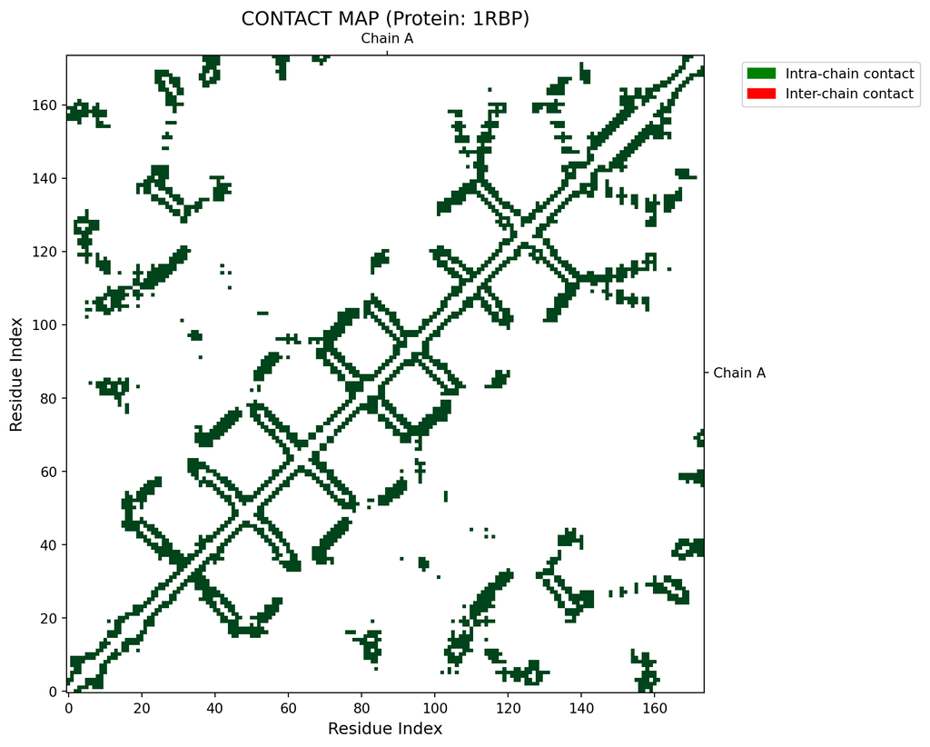

(a) Contact map for the protein 1RBP

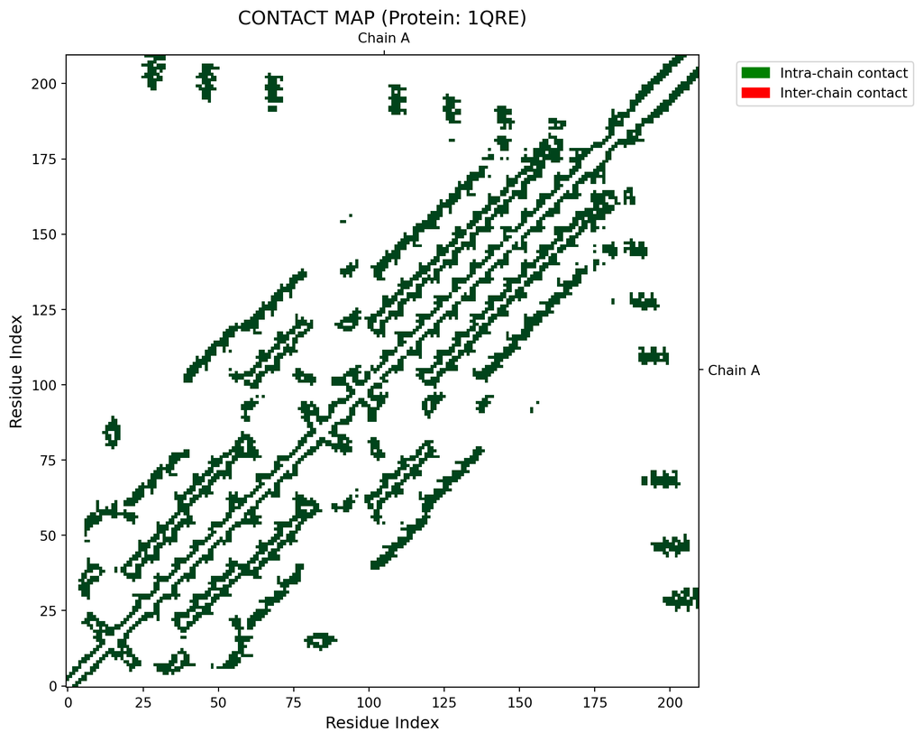

(b) Contact map for the protein 1QRE

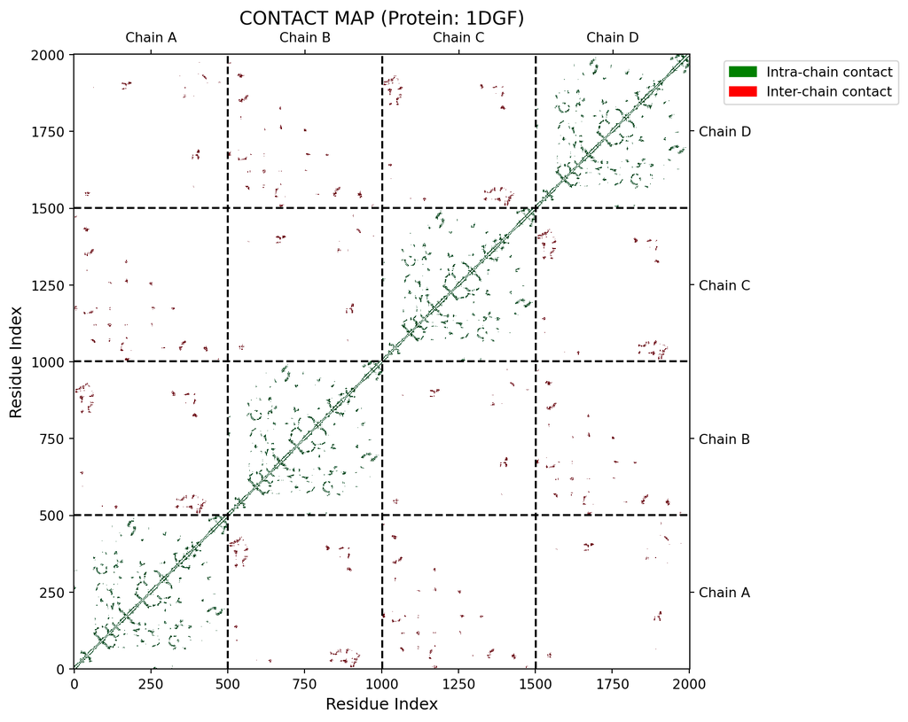

(c) Contact map for the protein 1DGF

Figure 1: Contact maps for the analyzed proteins (1RBP, 1QRE, 1DGF).

```python
pdb_list = ["1RBP", "1QRE", "1DGF"]
for id in pdb_list:
    df_struct_info = get_structural_info(id)
    num_chains = df_struct_info["chain"].nunique()

    #print(f"PDB ID: {id} | Number of chains: {num_chains}")

    dist_matrix = distance_matrix(df_struct_info)
    intra_contact_matrix, inter_contact_matrix = contact_matrix(df_struct_info, dist_matrix)

    plot_contact_map(df_struct_info, intra_contact_matrix, inter_contact_matrix, pdb_id=id)

    plt.show()
    plt.close('all')
```

The 1RBP protein contact map (Figure 1 (a)) shows discrete segments oriented perpendicularly to the main diagonal. These patterns are the classic “signature” of antiparallel $\beta$-sheets, which in this case constitute the eight-stranded $\beta$-barrel that forms the protein’s central cavity. The regular spacing between the off-diagonal clusters indicates the highly organized hydrogen-bonding network between adjacent $\beta$-strands. The contacts between the first and the last strands are also visible as distal signals. This represents the closed barrel structure. Furthermore, in the C-terminal region, the main diagonal exhibits a distinct thickening, which represents the presence of an $\alpha$-helical segment in this specific area.

The 1QRE contact map (Figure 1 (b)) exhibits prominent clusters of contacts running parallel to the main diagonal. These patterns represent parallel $\beta$-sheets, which characterize the central core of the protein’s fold. A significant thickening is observed along the entire main diagonal. This indicates a high density of $(i, i+4)$ local interactions, representing the presence of multiple $\alpha$-helices packed against the central sheets. The plot displays three clearly defined blocks of contacts, within which several segments run parallel to the main diagonal; these patterns indicate the structural packing and close-range interactions between the $\alpha$-helices and $\beta$-sheets

The 1DGF contact map (Figure 1 (c)) reveals prominent segments oriented both parallel and perpendicular to the main diagonal. This dual pattern represents a complex $\alpha/\beta$ architecture, where the parallel lines indicate parallel $\beta$-sheets and the perpendicular segments confirm the presence of antiparallel $\beta$-strands within the same fold. A dense thickening is observed along the entire main diagonal, indicating the presence of multiple $\alpha$-helices, which are characterized by a high frequency of $(i, i+4)$ local interactions.

# 4 Discussion

This project has successfully implemented a computational approach to analyze protein architecture through the generation and interpretation of distance and contact matrices. By processing structural data from the PDB, we have achieved an efficient generation of contact maps, providing a clear visual representation of the complex three-dimensional folding of the studied proteins.

In particular, the developed pipeline was applied to characterize the intramolecular and intermolecular interaction patterns of proteins 1RBP, 1QRE, and 1DGF, effectively mapping their tertiary and quaternary organizations.

## 4.1 `1RBP`

The analysis of 1RBP (Retinol-Binding Protein) confirms its characteristic $\beta$-barrel tertiary structure. When compared to the reference data in the Protein Data Bank (PDB), where the structure was determined via X-ray diffraction at a high resolution of 2.0 Å, the generated contact map (Figure 1 (a)) precisely aligns with the experimentally observed conformation. The contact matrix highlights the $\beta$-barrel core where predominant anti-diagonal signals correspond to the eight antiparallel $\beta$-strands that wrap into a closed barrel, a hallmark of the lipocalin family. In addition to the barrel, the map identifies a specific $\alpha$-helical zone located near the C-terminus. This is visible in the contact map as a localized area of increased density along the main diagonal, representing the short-range $(i, i+4)$ interactions characteristic of helical turns.

## 4.3 `1DGF`

The last one, the 1DGE contact map (Figure 1 (c)) reveals a quaternary structure composed of four identical subunits, identifying it as a homotetramer. This observation is highly consistent with the experimentally resolved structure obtained via X-ray diffraction at a high resolution of 1.5 Å. Both the 3D visualization in the PDB and the contact map exhibit a fold characterized by antiparallel $\beta$-sheets organized into a barrel structure. These structural elements are packed against $\alpha$-helices, which further facilitate inter-helical interactions. Furthermore, the PDB data illustrates how the monomers interact; they show a higher density of contacts with adjacent subunits and a significantly lower degree of contact with the monomer located diagonally across the assembly. Consequently, the patterns depicted in the contact map align perfectly with the experimental structure archived in the PDB.

Furthermore, contact maps facilitate the identification of recurring structural patterns and the characterization of inter-chain contacts within the quaternary structure. The close agreement between these contact maps and the high-resolution, experimentally resolved structures archived in the PDB underscores the utility of distance-based matrices for elucidating the intricate interactions and architectures of proteins.

# 5 Conclusion

In this project, we have successfully developed a robust computational pipeline to analyze protein structures through distance and contact matrices. By leveraging Python and structural data from the PDB, we achieved the efficient generation of contact maps, providing a clear visual representation of complex three-dimensional folds. A critical aspect of this work was the implementation of a coherent distance filtering strategy. By applying thresholds between 6 and 12 Å, we effectively eliminated structural noise, retaining only the biologically significant interactions. This allowed for a precise distinction between intra-chain (tertiary) and inter-chain (quaternary) contacts, pinpointing the exact regions responsible for subunit packing and overall complex stabilization.The results demonstrate that contact maps are powerful tools for structural biology, as they condense thousands of atomic coordinates into identifiable geometric patterns—such as the characteristic signatures of $\alpha$-helices and $\beta$-sheets. In conclusion, the methodologies applied in this study provide a reliable and scalable framework for the comparative analysis of protein architectures and their functional interfaces.

# 6 Annexes

## 6.1 Work Register

The development of this project has followed a workflow managed via GitHub, in order it can be reproduced.

The following table sumarizes the main stages of the project.

|  | Phase | Description |
| --- | --- | --- |
| 0 | Setup | Repository initialization and project structuring |
| 1 | Metadata | Access to each protein key information via API... |
| 2 | Protein structural information | Get access to PDB files and parse them to gen ... |
| 3 | Distance matrix | Compute the distances matrix between Cα atoms |
| 4 | Contact maps | Plot intra/interchain contacts giving a threshold |
| 5 | Report writing | Create the final file and include all the prev... |

Every modification is documented through a descriptive commit message.

**Repository Access**: https://github.com/MCML-Projects/STRBIO.git